# Coursera Data Science Capstone Project - Milestone Report

Jack

October 19, 2016

## Introduction

Portable office actually means the works done on the cellphone and the tablet and we need input system to saving our time on typing on them. So a smart and efficient keyboard is required and the core of this input system is a predictive text model. This milestone report is focused on this model, covering the very beginning, namely data collection, to exploratory analysis of the data set.

## Data Collection

The data were downloaded from the course website (from [HC Corpora](http://www.corpora.heliohost.org)) and unzipped to extract the English database as a corpus. Three text documents from the twitter, blog and news were found with each line standing for a message.

## Load Data

- It is assumed that the encoding of the dataset is UTF-8
- Load each file one by one using readLines function

## Summary

The basic summary of the orginal data set is shown as follows:

Summary of the datasets

| Dataset | Lines | Chars | Words |
| --- | --- | --- | --- |
| blogsdoc | 899288 | 206824382 | 37570839 |
| newsdoc | 1010242 | 203223154 | 34494539 |
| twittersdoc | 2360148 | 162096241 | 30451170 |

## Data Cleansing

The data will be filtered by

- 1)Sampling the data by 1% of three documents(3 files), example code -sample(blogs_sample, length(blogs_sample) * 0.01.
- 2)the non-ASCII characters
- 3)change the capital characters to lower case
- 4)remove the punctuation
- 5)numbers
- 6)stop words
- 7)stemming the left words.
- 8)To decrease the spares of the term frequency

## Tokenizer

The whole tokenization is aiming at removing meaningless characters and the words with low frequency in the corpus. The final corpus will show the words or n-gram with a high frequency which will be helpful for exploring the relationship between the words and building a manful statistical model.

## Exploratory analysis

### Figure 1 Histogram of nGrams(Top 10)

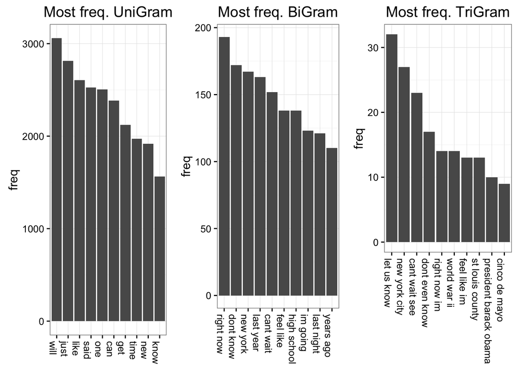

### Figure 2 WordCloud of nGrams(Top 10)

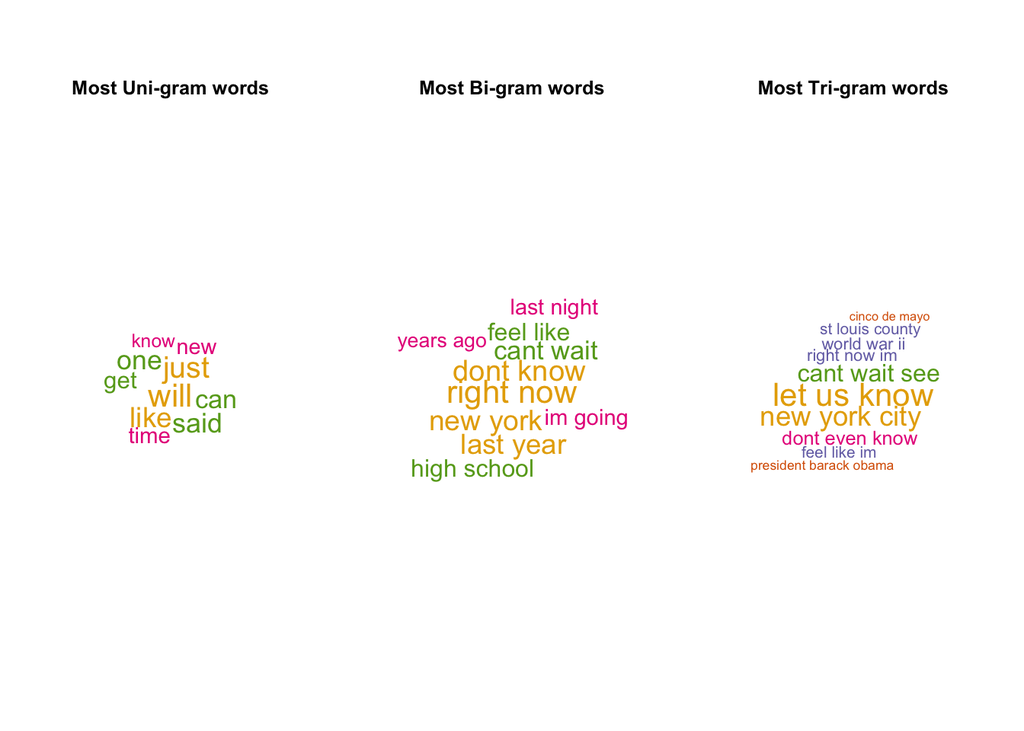

## Interest Findings

- Scability. Feels like the real big data , in which running such scale of data in the desktop PC.
- Integrity. The data cleansing step is very import to obtain accurate data.

## Next Steps for the Prediction Application

- As already noted, the next step of the capstone project will be to create a prediction application. To create a smooth and fast application it is absolutely necessary to build a fast prediction algorithm.
- Thus, find ways for a faster processing of larger datasets is necessary. Therefore, evaluate the suitable is very important. In this project the following Algorithms will be evaluated :
- Markov Assumption algorithm (https://en.wikipedia.org/wiki/Markov_property)
- chain Rule
- Katz’s Backoff Model (https://thachtranerc.wordpress.com/2016/04/12/katzs-backoff-model-implementation-in-r/)
- smoothing technique (http://nlp.stanford.edu/~wcmac/papers/20050421-smoothing-tutorial.pdf)
- All in all a shiny application will be created which will be able to predict the next word a user wants to write.